# Size selection results

J. Ignacio Lucas Lledó

27/10/2021

The genomics unit at the University of Valencia delivered the five pools and their quantification with Bioanalyser. The image below shows the fragment size profiles, in order.

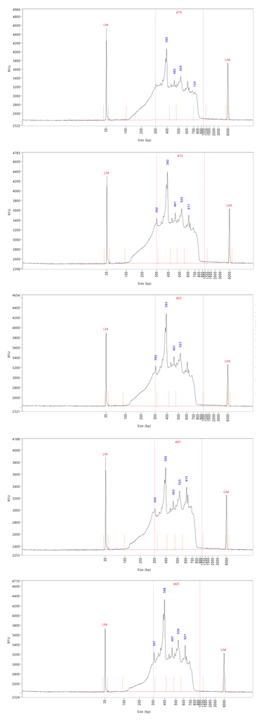

The profiles are remarkably similar, which suggests an overall success in library construction. The aparently longer tail on the left margin of the size distribution may be an effect of the axis scale. Fragments below 300 bp, which will be for the most part assembled from the two reads are the random remains of what the Blue Pippin could not remove. Thus, they are not expected to be shared among samples, and will be discarded.

On the right margin, I expected fragments up to 1000 bp, and I wonder if the operation of the BluePippin did not match the exact specification. The abrupt cut at 800 bp makes me suspect so. In any case, it is too late to lament.

About concentrations:

```r
pools <- read.table('../../data/FinalPoolConcentrations.tsv', header = TRUE)
kable(pools, col.names = c('Pool','Total conc. (ng/µl)', 'Total Molarity (nmol/l)',
                           'Conc. 300-1000 bp (ng/µl)', 'Molarity 300-1000 (nmol/l)',
                           'Average size (bp)'))
```

| Pool | Total conc. (ng/µl) | Total Molarity (nmol/l) | Conc. 300-1000 bp (ng/µl) | Molarity 300-1000 (nmol/l) | Average size (bp) |
| --- | --- | --- | --- | --- | --- |
| 1 | 4.0370 | 17.2373 | 3.0328 | 10.4092 | 479 |
| 2 | 5.2237 | 23.5119 | 3.8578 | 13.3539 | 475 |
| 3 | 5.5192 | 24.7646 | 4.1228 | 14.5733 | 465 |
| 4 | 4.6422 | 20.1293 | 3.5143 | 11.8624 | 487 |
| 5 | 5.5202 | 23.6290 | 4.4933 | 15.7581 | 469 |

They are quite even, but they can be better balanced. Thus, I decide to equilibrate the five pools. Total volumes seem to range between 40 and 45 µl. The question is if I should balance the total concentration or the concentration in the 300 to 1000 bp range. I decide to balance molarity in the target range, with the hope of getting a similar amount of useful reads among pools.

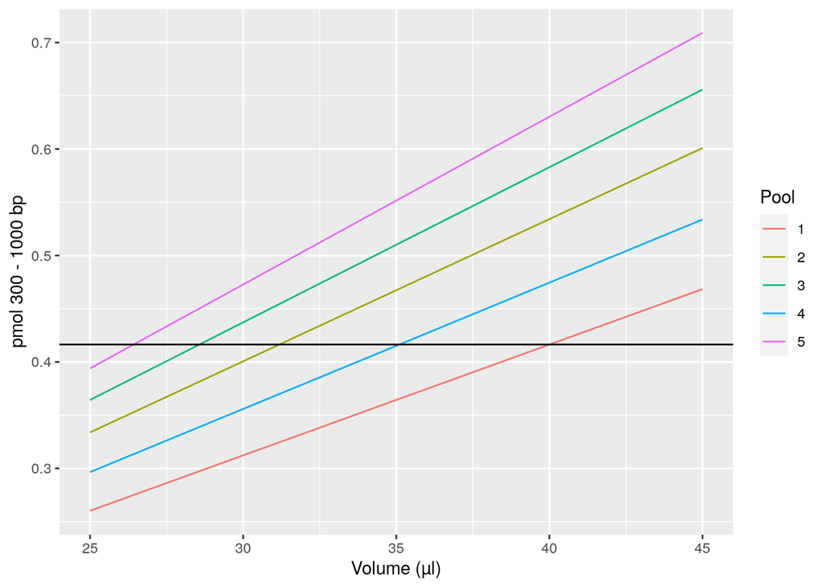

```r
Amounts <- data.frame(
  Volume     = rep(25:45, 5),
  Pool       = factor(rep(1:5, each = 21)),
  Tot.ng     = do.call(c, lapply(1:5, function(x) pools[x, 'total.ng.ul']  * (25:45))),
  Tot.pmol   = do.call(c, lapply(1:5, function(x) pools[x, 'total.nmol.l'] * 1.0e-03 * (25:45))),
  Range.ng   = do.call(c, lapply(1:5, function(x) pools[x, 'range.ng.ul']  * (25:45))),
  Range.pmol = do.call(c, lapply(1:5, function(x) pools[x, 'range.nmol.l'] * 1.0e-03 * (25:45)))
)

Target.pmol <- 40 * pools[1, 'range.nmol.l'] * 1.0e-03
Target.volume <- Target.pmol / (pools[,'range.nmol.l'] * 1.0e-03)

ggplot(data = Amounts, mapping = aes(x = Volume, y = Range.pmol, color = Pool)) +
  geom_line() + geom_hline(yintercept = Target.pmol) +
  xlab("Volume (µl)") + ylab("pmol 300 - 1000 bp")
```

```r
kable(data.frame(Pool = 1:5, Volume = Target.volume))
```

| Pool | Volume |
| --- | --- |
| 1 | 40.00000 |
| 2 | 31.17951 |
| 3 | 28.57061 |
| 4 | 35.09981 |
| 5 | 26.42247 |

Pool number 1 is the less concentrated one, and it determines the amounts required from the other pools to reach the same molarity in the size range between 300 and 1000 bp. The volumes above are the ones used from each partial pool to create the final pool. Thus, the final volume is 161.3 $\mu$l, it must contain 2.08 pmol in all, and its concentration must therefore be 12.91 nmol/l.

The pool and the sequencing primers were delivered in the sequencing center on October 28th, 2021.